# Preliminary data summary: Aggregated data

## Overview

In this file we look at some of the aggregate data summaries. Let us first define this in terms of the basic units of analysis. The LIDD dataset is structured according to a “country X instrument” combination, which we can think of as “cases”. Depending on the instrument, every “country X instrument” combination has between 44 and 72 items associated with it (i.e., the questions we ask per instrument). In the data summaries below we will just look at the cases, i.e., the “country X instrument” combination and ignore the items.

The median number of DD instruments across the CoE is 4 (the mean average is 3.4).

#### Number of DD instruments per country

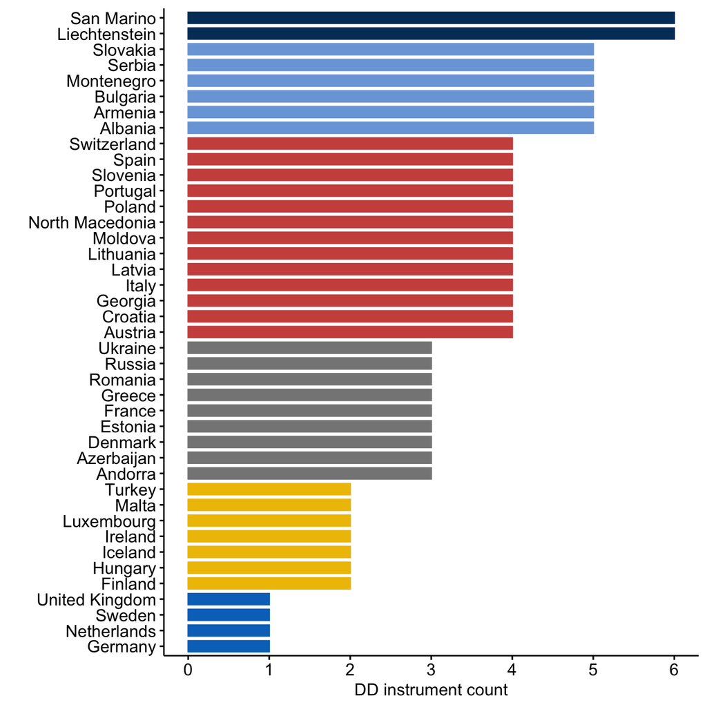

Another aggregate distribution of interest is the prevalence of each instrument across the CoE. The legislature-initiated and (quite surprisingly) the Agenda initiative are the most popular, while Subnational and Rejective are the least popular. Evidently, if we re-categorised the Rejective and Proactive instruments as a single bottom-up initiative the number would be more equally distributed.

#### Number of countries by DD instrument

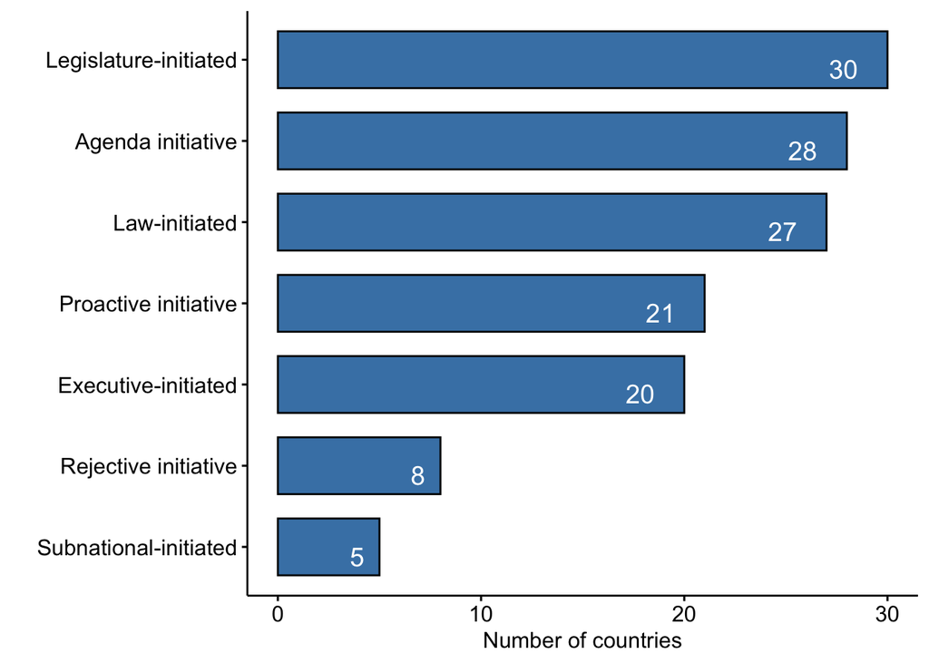

## Dimensions

So far we have calculated four dimensions: 1) Formal limits; 2) Formal procedures; 3) Substantive limits; and 4) Substantive procedures. The scores for these dimensions can be seen in the graphs below. Note: these are still tentative calculations since the items that define the dimensions have not yet been finalised by the team.

#### Four dimensions grouped by instrument

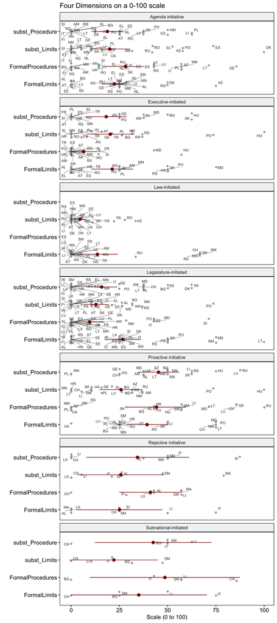

# Annex

### The bottom-up initiative

The N of bottom-up initiatives is 25 if we combine Rejective and Proactive initiatives.

#### Countries with both Rejective and Proactive

| Row_id | Country |
| --- | --- |
| 1 | Albania |
| 2 | Liechtenstein |
| 3 | San Marino |
| 4 | Switzerland |

#### Countries with only one bottom-up initiative

| Row_id | Country |
| --- | --- |
| 1 | Armenia |
| 2 | Azerbaijan |
| 3 | Bulgaria |
| 4 | Croatia |
| 5 | Georgia |
| 6 | Hungary |
| 7 | Italy |
| 8 | Latvia |
| 9 | Lithuania |
| 10 | Luxembourg |
| 11 | Malta |
| 12 | Moldova |
| 13 | Montenegro |
| 14 | North Macedonia |
| 15 | Poland |
| 16 | Portugal |
| 17 | Russia |
| 18 | Serbia |
| 19 | Slovakia |
| 20 | Slovenia |
| 21 | Ukraine |